## **Input Genomic Region Information**

Completed on Thu Apr 06 21:30:35 2023 (Asia/Shanghai), with the runtime of 20 seconds.

> **An interactive table** for user-input genomic regions (n=381, being processed). The table includes three columns: 1st column `Input GR` for input genomic regions in the format of `chr:start-end` (the genome build `hg19`), 2nd column `Chromosome` for the chromosome, 3rd `Length` for the region length (bp).

| Input GR | Chromosome | Length |
| --- | --- | --- |
| chr20:4090134-4092134 | chr20 | 2001 |
| chr11:117973237-117975237 | chr11 | 2001 |
| chr1:212634309-212636309 | chr1 | 2001 |
| chr1:212635821-212637821 | chr1 | 2001 |
| chr17:36127082-36129082 | chr17 | 2001 |
| chr20:4081996-4083996 | chr20 | 2001 |
| chr17:36143118-36145118 | chr17 | 2001 |
| chr17:36132988-36134988 | chr17 | 2001 |
| chr1:212637708-212639708 | chr1 | 2001 |
| chr2:113097209-113099209 | chr2 | 2001 |

[output cut: 371 more lines]

## **Output: Linked Genes**

> **Linked Gene table** contains information on genes (n=408, linked from input genomic regions), including the column `GScores` (ranged from 1 to 10) that quantifies the degree to which genes are likely modulated by input genomic regions. `Linked genes` are sorted by their linked gene scores and are hyperlinked to [GeneCards](https://www.genecards.org) for further information. Please refer to **`Evidence table`** for details on the linking evidence.

| Linked genes | GScores | Description |
| --- | --- | --- |
| SPARCL1 | 10 | SPARC like 1 |
| ACTB | 4.507 | actin beta |
| LINC00886 | 3.93 | long intergenic non-protein coding RNA 886 |
| ADAMDEC1 | 3.921 | ADAM like decysin 1 |
| WTIP | 3.847 | WT1 interacting protein |
| ETV3 | 3.809 | ETS variant transcription factor 3 |
| PA2G4P4 | 3.789 | proliferation-associated 2G4 pseudogene 4 |
| TMPRSS4 | 3.696 | transmembrane serine protease 4 |
| PPP1R11 | 3.531 | protein phosphatase 1 regulatory inhibitor subunit 11 |
| FBXL18 | 3.482 | F-box and leucine rich repeat protein 18 |

[output cut: 398 more lines]

> **Evidence table** displays information about the genomic regions (listed under the column `GR`) that overlap the input genomic regions (listed under the column `Input GR`). The overlapped regions are used to define linked genes (listed under the column `Linked genes`) based on the evidence provided (see the column `Evidence`). The column `Evidence` indicates the datasets used, such as `Proximity` for genomic regions in proximity, the prefix `PCHiC_` for promoter capture Hi-C datasets, and the prefix `ABC_` for enhancer-gene map (ABC) datasets.

| Input GR | GR | Linked genes | Evidence |
| --- | --- | --- | --- |
| chr4:88446584-88448584 | chr4:88446477-88447338 | SPARCL1 | ABC_Encode_Combined |
| chr4:88446584-88448584 | chr4:88446722-88446922 | SPARCL1 | ABC_Encode_Combined |
| chr4:88446584-88448584 | chr4:88446791-88447091 | SPARCL1 | ABC_Encode_Combined |
| chr4:88446584-88448584 | chr4:88446795-88447072 | SPARCL1 | ABC_Encode_Combined |
| chr4:88446584-88448584 | chr4:88446798-88446998 | SPARCL1 | ABC_Encode_Combined |
| chr4:88446584-88448584 | chr4:88446820-88447020 | SPARCL1 | ABC_Encode_Combined |
| chr4:88446584-88448584 | chr4:88446838-88447038 | SPARCL1 | ABC_Encode_Combined |
| chr4:88446584-88448584 | chr4:88447132-88447332 | SPARCL1 | ABC_Encode_Combined |
| chr4:88446584-88448584 | chr4:88447455-88447655 | SPARCL1 | ABC_Encode_Combined |
| chr4:88446584-88448584 | chr4:88448255-88448455 | SPARCL1 | ABC_Encode_Combined |

[output cut: 1306 more lines]

## **Output: Enriched Terms**

> **An interactive table** that displays enriched ontology terms based on 408 linked genes. Each enriched term (the columns `Ontology`, `Term ID` and `Term Name`) has the enrichment z-score (`Z-score`), the enrichment significance level (`FDR`), odds ratio (`Odds ratio`) and 95% confidence intervals (`95% CI`), the number (`Num`) and list (`Members`) of member genes that overlap with linked genes. The table is sorted by FDR ascendingly.

| Ontology | Term ID | Term Name | Z-score | FDR | Odds ratio | 95% CI | Num | Members |
| --- | --- | --- | --- | --- | --- | --- | --- | --- |
| EnvironmentalOrganismal | path:hsa04610 | Complement and coagulation cascades | 4.73 | 0.02 | 5.67 | [2.13, 12.9] | 7 | C4BPA, C4BPB, CD59, CR1, CR1L, CR2, THBD |
| EnvironmentalOrganismal | path:hsa04630 | JAK-STAT signaling pathway | 3.89 | 0.029 | 3.77 | [1.62, 7.8] | 9 | CDKN1A, CISH, IL10, IL10RA, IL19, IL20, IL7, IL7R, PIM1 |
| EnvironmentalOrganismal | path:hsa04068 | FoxO signaling pathway | 3.3 | 0.064 | 3.53 | [1.34, 7.91] | 7 | CAT, CDKN1A, FBXO25, IL10, IL7R, RAG1, SKP2 |
| EnvironmentalOrganismal | path:hsa04061 | Viral protein interaction with cytokine and cytokine receptor | 3.39 | 0.064 | 3.96 | [1.37, 9.41] | 6 | IL10, IL10RA, IL19, IL20, TNFRSF10B, TNFRSF10D |
| EnvironmentalOrganismal | path:hsa04060 | Cytokine-cytokine receptor interaction | 2.82 | 0.078 | 2.48 | [1.16, 4.82] | 11 | AMH, BMP6, IL10, IL10RA, IL17B, IL19, IL20, IL7, IL7R, TNFRSF10B, TNFRSF10D |
| EnvironmentalOrganismal | SignalTransduction | Signal transduction | 2.18 | 0.13 | 1.67 | [1.02, 2.77] | 40 | ACTB, ADCYAP1R1, AMH, AVPR1B, BMP6, CAT, CBY1, CDKN1A, CISH, CRHR2, DCN, DGKD, FBXO25, FXYD2, HEY1, IL10, IL10RA, IL19, IL20, IL7, IL7R, IMPA1, ITGB8, MAPKAPK2, MAPKAPK3, PFKFB2, PGF, PIM1, PPP2R5A, P… |
| EnvironmentalOrganismal | SignalingMoleculesAndInteraction | Signaling molecules and interaction | 1.81 | 0.3 | 1.6 | [0.909, 2.72] | 21 | ADCYAP1R1, AMH, AVPR1B, BMP6, CD44, CRHR2, GHRHR, GLRB, IL10, IL10RA, IL17B, IL19, IL20, IL7, IL7R, ITGB8, SDC1, SIGLEC1, SPP1, TNFRSF10B, TNFRSF10D |
| EnvironmentalOrganismal | path:hsa04512 | ECM-receptor interaction | 2.1 | 0.3 | 2.87 | [0.744, 7.98] | 4 | CD44, ITGB8, SDC1, SPP1 |
| EnvironmentalOrganismal | path:hsa04657 | IL-17 signaling pathway | 1.95 | 0.31 | 2.68 | [0.695, 7.42] | 4 | IKBKE, IL17B, TRAF5, TRAF6 |
| EnvironmentalOrganismal | path:hsa04370 | VEGF signaling pathway | 2.04 | 0.31 | 3.21 | [0.627, 10.3] | 3 | MAPKAPK2, MAPKAPK3, PRKCG |

[output cut: 30 more lines]

## **Output: Dotplot**

> **A dotplot** of enriched ontology terms identified using Fisher’s exact test. An editable pdf file is also available for download.

DOWNLOAD .pdf

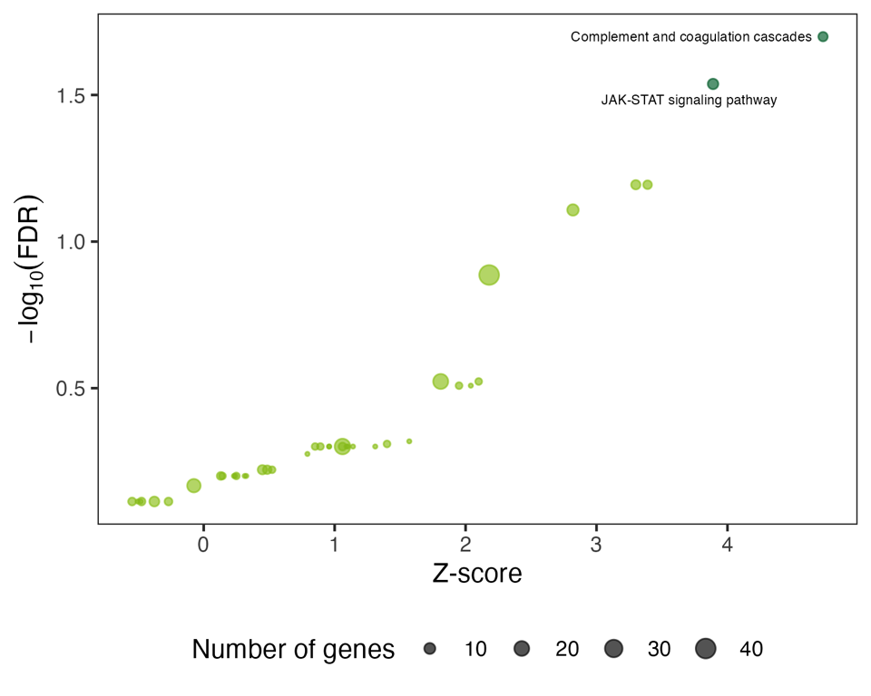

Figure 1: A dotplot of enriched ontology terms. The dots colored in dark green represent the terms with FDR < 0.05, indicating statistical significance. The top 5 significant terms (ordered by FDR ascendingly) are labelled for easier interpretation.

## **Output: Forest Plot**

> **A forest plot** of enriched ontology terms identified using Fisher’s exact test. An editable pdf file is also available for download.

DOWNLOAD .pdf

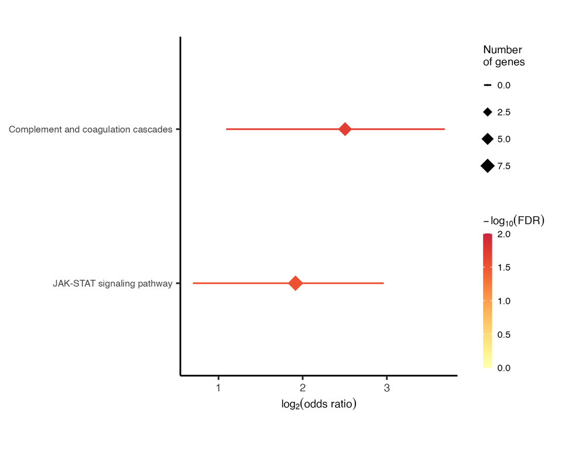

Figure 2: Forest plot for enriched ontology terms (ordered by odds ratio descendingly).